# Project1CamLee

```python
import numpy as np
import pandas as pd
import matplotlib.pyplot as plt
import seaborn as sns
from sklearn.model_selection import train_test_split
from sklearn.linear_model import LogisticRegression
from sklearn.tree import DecisionTreeClassifier
from sklearn.preprocessing import StandardScaler
from sklearn.metrics import accuracy_score, precision_score, recall_score, f1_score, ConfusionMatrixDisplay
from sklearn.metrics import classification_report
from sklearn.metrics import confusion_matrix
```

```python
from google.colab import drive
drive.mount('/content/drive')
```

```python
penguins = sns.load_dataset('penguins')
```

```python
penguins.head()
```

|  | species | island | bill_length_mm | bill_depth_mm | flipper_length_mm | body_mass_g | sex |
| --- | --- | --- | --- | --- | --- | --- | --- |
| 0 | Adelie | Torgersen | 39.1 | 18.7 | 181.0 | 3750.0 | Male |
| 1 | Adelie | Torgersen | 39.5 | 17.4 | 186.0 | 3800.0 | Female |
| 2 | Adelie | Torgersen | 40.3 | 18.0 | 195.0 | 3250.0 | Female |
| 3 | Adelie | Torgersen | NaN | NaN | NaN | NaN | NaN |
| 4 | Adelie | Torgersen | 36.7 | 19.3 | 193.0 | 3450.0 | Female |

```python
penguins.describe()
```

|  | bill_length_mm | bill_depth_mm | flipper_length_mm | body_mass_g |
| --- | --- | --- | --- | --- |
| count | 342.000000 | 342.000000 | 342.000000 | 342.000000 |
| mean | 43.921930 | 17.151170 | 200.915205 | 4201.754386 |
| std | 5.459584 | 1.974793 | 14.061714 | 801.954536 |
| min | 32.100000 | 13.100000 | 172.000000 | 2700.000000 |
| 25% | 39.225000 | 15.600000 | 190.000000 | 3550.000000 |
| 50% | 44.450000 | 17.300000 | 197.000000 | 4050.000000 |
| 75% | 48.500000 | 18.700000 | 213.000000 | 4750.000000 |
| max | 59.600000 | 21.500000 | 231.000000 | 6300.000000 |

```python
penguins.info()
```

```
<class 'pandas.core.frame.DataFrame'>
RangeIndex: 344 entries, 0 to 343
Data columns (total 7 columns):
 #   Column             Non-Null Count  Dtype
---  ------             --------------  -----
 0   species            344 non-null    object
 1   island             344 non-null    object
 2   bill_length_mm     342 non-null    float64
 3   bill_depth_mm      342 non-null    float64
 4   flipper_length_mm  342 non-null    float64
 5   body_mass_g        342 non-null    float64
 6   sex                333 non-null    object
dtypes: float64(4), object(3)
memory usage: 18.9+ KB
```

```python
penguins.shape
```

```
(344, 7)
```

```python
penguins.isna().sum()
```

|  | 0 |
| --- | --- |
| species | 0 |
| island | 0 |
| bill_length_mm | 2 |
| bill_depth_mm | 2 |
| flipper_length_mm | 2 |
| body_mass_g | 2 |
| sex | 11 |

**dtype:** int64

```python
penguins_clean = penguins.dropna(subset=["species"])
penguins_clean = penguins.dropna(subset=["species"])


cols_needed = [
    "bill_length_mm",
    "bill_depth_mm",
    "flipper_length_mm",
    "body_mass_g",
    "sex",
    "island"
]
penguins_clean = penguins_clean.dropna(subset=cols_needed)

penguins_clean.isna().sum(), penguins_clean.shape
```

```
(species              0
 island               0
 bill_length_mm       0
 bill_depth_mm        0
 flipper_length_mm    0
 body_mass_g          0
 sex                  0
 dtype: int64,
 (333, 7))
```

There are some missing values in the dataset.  
To keep things simple and clear for this project, I will:

Keep only rows that have a species label Drop rows that are missing any of the key variables I want to use:

- bill_length_mm
- bill_depth_mm
- flipper_length_mm
- body_mass_g
- island
- sex

```python
penguins_clean["species"].value_counts()
```

| species | count |
| --- | --- |
| Adelie | 146 |
| Gentoo | 119 |
| Chinstrap | 68 |

**dtype:** int64

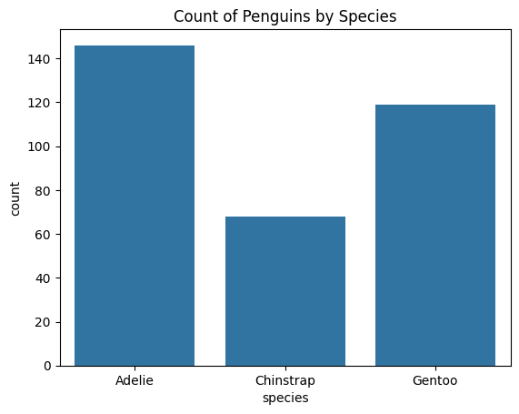

```python
sns.countplot(data=penguins_clean, x="species")
plt.title("Count of Penguins by Species")
plt.show()
```

The bar plot shows how many penguins we have from each species.  
The classes are not perfectly balanced, but each species (Adelie, Chinstrap, Gentoo) has a reasonable number of samples. This is helpful for building classification models because we are not trying to learn from only a few examples.

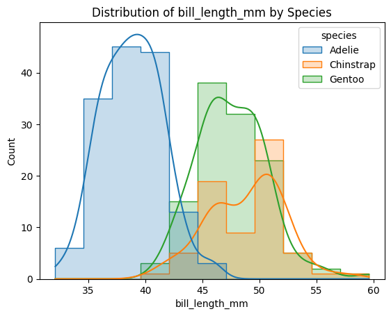

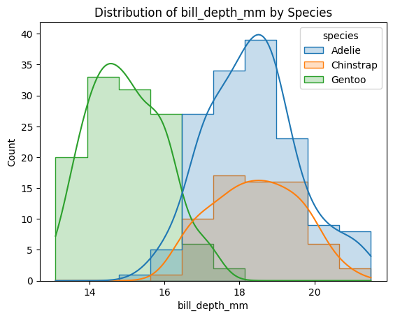

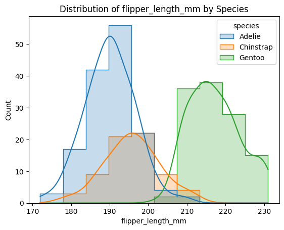

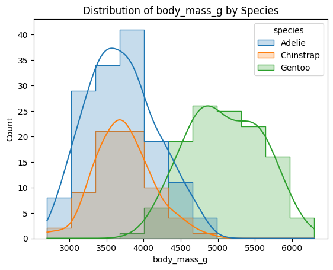

```python
numeric_cols = ["bill_length_mm", "bill_depth_mm", "flipper_length_mm", "body_mass_g"]

for col in numeric_cols:
    sns.histplot(
        data=penguins_clean,
        x=col,
        hue="species",
        kde=True,
        element="step"
    )
    plt.title(f"Distribution of {col} by Species")
    plt.show()
```

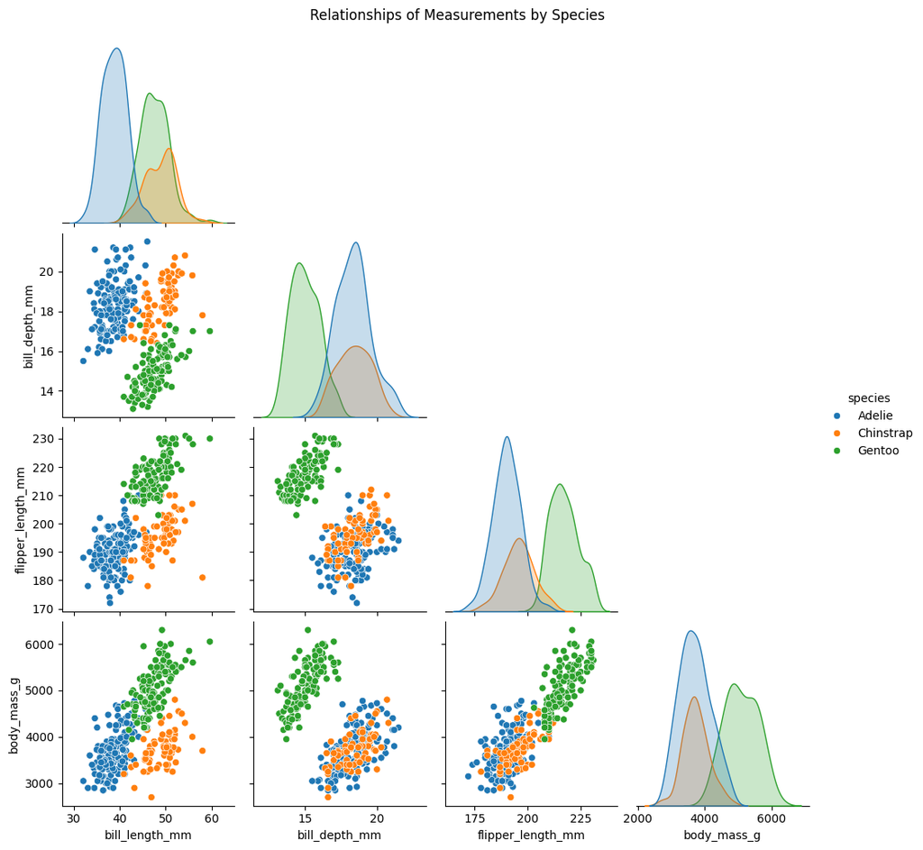

```python
sns.pairplot(
    penguins_clean,
    vars=["bill_length_mm", "bill_depth_mm", "flipper_length_mm", "body_mass_g"],
    hue="species",
    corner=True
)
plt.suptitle("Relationships of Measurements by Species", y=1.02)
plt.show()
```

The histograms and pairplot show clear differences between species:

Gentoo penguins tend to have longer flippers and higher body mass.  
Adelie and Chinstrap penguins have more overlap, but still show differences in bill length and bill depth.

These patterns suggest that physical measurements should be useful features for predicting species.

```python
target_col = "species"
feature_cols = [
    "bill_length_mm",
    "bill_depth_mm",
    "flipper_length_mm",
    "body_mass_g",
    "island",
    "sex"
]

data = penguins_clean[feature_cols + [target_col]].copy()
data_encoded = pd.get_dummies(data, columns=["island", "sex"], drop_first=True)

X = data_encoded.drop(columns=[target_col])
y = data_encoded[target_col]

X.head(), y.head()
```

```
(   bill_length_mm  bill_depth_mm  flipper_length_mm  body_mass_g  \
 0            39.1           18.7              181.0       3750.0
 1            39.5           17.4              186.0       3800.0
 2            40.3           18.0              195.0       3250.0
 4            36.7           19.3              193.0       3450.0
 5            39.3           20.6              190.0       3650.0

    island_Dream  island_Torgersen  sex_Male
 0         False              True      True
 1         False              True     False
 2         False              True     False
 4         False              True     False
 5         False              True      True  ,
 0    Adelie
 1    Adelie
 2    Adelie
 4    Adelie
 5    Adelie
 Name: species, dtype: object)
```

```python
X_train, X_test, y_train, y_test = train_test_split(
    X, y,
    test_size=0.25,
    random_state=42,
    stratify=y
)
numeric_features = ["bill_length_mm", "bill_depth_mm", "flipper_length_mm", "body_mass_g"]

scaler = StandardScaler()

X_train_scaled = X_train.copy()
X_test_scaled = X_test.copy()

X_train_scaled[numeric_features] = scaler.fit_transform(X_train[numeric_features])
X_test_scaled[numeric_features] = scaler.transform(X_test[numeric_features])

X_train_scaled.head()
```

|  | bill_length_mm | bill_depth_mm | flipper_length_mm | body_mass_g | island_Dream | island_Torgersen | sex_Male |
| --- | --- | --- | --- | --- | --- | --- | --- |
| 185 | 1.268845 | 0.793535 | 0.116192 | -0.154828 | True | False | True |
| 39 | -0.757819 | 0.945567 | -1.237764 | 0.525870 | True | False | True |
| 319 | 1.286940 | -0.372040 | 1.683931 | 1.268450 | False | False | True |
| 89 | -0.920676 | 0.793535 | -0.810199 | -0.773645 | True | False | False |
| 169 | 2.535510 | 0.286764 | -1.451546 | -0.649882 | True | False | False |

```python
log_reg = LogisticRegression(max_iter=1000, multi_class="multinomial")

log_reg.fit(X_train_scaled, y_train)
y_pred_log = log_reg.predict(X_test_scaled)

log_acc = accuracy_score(y_test, y_pred_log)
print(f"Logistic Regression Accuracy: {log_acc:.3f}")
print("\nClassification Report (Logistic Regression):")
print(classification_report(y_test, y_pred_log))
```

```
Logistic Regression Accuracy: 1.000

Classification Report (Logistic Regression):
              precision    recall  f1-score   support

      Adelie       1.00      1.00      1.00        37
   Chinstrap       1.00      1.00      1.00        17
      Gentoo       1.00      1.00      1.00        30

    accuracy                           1.00        84
   macro avg       1.00      1.00      1.00        84
weighted avg       1.00      1.00      1.00        84
```

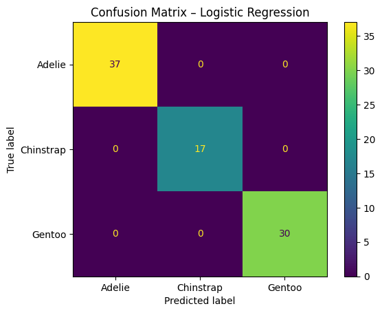

```python
cm_log = confusion_matrix(y_test, y_pred_log, labels=log_reg.classes_)
disp_log = ConfusionMatrixDisplay(confusion_matrix=cm_log, display_labels=log_reg.classes_)
disp_log.plot()
plt.title("Confusion Matrix – Logistic Regression")
plt.show()
```

```python
tree_clf = DecisionTreeClassifier(
    max_depth=4,
    random_state=42
)

tree_clf.fit(X_train, y_train)
y_pred_tree = tree_clf.predict(X_test)

tree_acc = accuracy_score(y_test, y_pred_tree)
print(f"Decision Tree Accuracy: {tree_acc:.3f}")
print("\nClassification Report (Decision Tree):")
print(classification_report(y_test, y_pred_tree))
```

```
Decision Tree Accuracy: 0.976

Classification Report (Decision Tree):
              precision    recall  f1-score   support

      Adelie       0.95      1.00      0.97        37
   Chinstrap       1.00      1.00      1.00        17
      Gentoo       1.00      0.93      0.97        30

    accuracy                           0.98        84
   macro avg       0.98      0.98      0.98        84
weighted avg       0.98      0.98      0.98        84
```

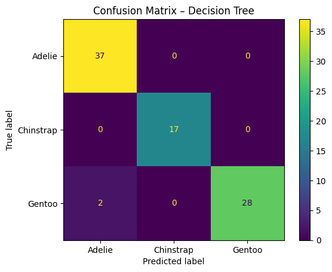

```python
cm_tree = confusion_matrix(y_test, y_pred_tree, labels=tree_clf.classes_)
disp_tree = ConfusionMatrixDisplay(confusion_matrix=cm_tree, display_labels=tree_clf.classes_)
disp_tree.plot()
plt.title("Confusion Matrix – Decision Tree")
plt.show()
```

```python
results = pd.DataFrame({
    "Model": ["Logistic Regression", "Decision Tree"],
    "Accuracy": [log_acc, tree_acc]
})

results
```

|  | Model | Accuracy |
| --- | --- | --- |
| 0 | Logistic Regression | 1.00000 |
| 1 | Decision Tree | 0.97619 |

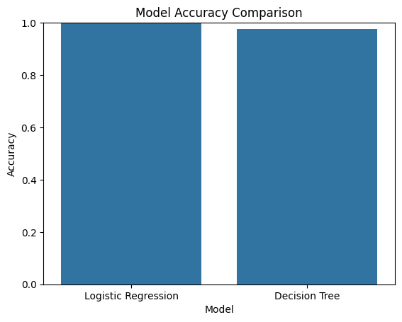

```python
sns.barplot(data=results, x="Model", y="Accuracy")
plt.ylim(0, 1)
plt.title("Model Accuracy Comparison")
plt.show()
```

Both models did a good job of predicting penguin species from the chosen features.

Logistic Regression achieved an accuracy of about 1

Decision Tree achieved an accuracy of about 0.976

Overall, logistic regression slightly outperforms the decision tree in this setup, but both models display that physical measurements and simple categorical features are strong predictors of species.

```python
! pip install nbconvert
# Convert this notebook to HTML
! jupyter nbconvert --to html "/content/drive/MyDrive/Colab Notebooks/Project1CamLee.ipynb " --output project
```

[output not shown]